# Assignment 1

I have selected the following three datasets, all of which are in the WGS 84 coordinate reference system:

1. A set of polygons representing national boundaries in Africa (shown below as gray polygons with black borders). They are downloaded from Natural Earth Data via the rnaturalearth package as R simple features. The dataset includes 51 polygons, each representing a country. There are 64 variables, including the following that I might include in future analyses:
   - pop_est: The estimated population
   - gdp_md_est: The estimated GDP in millions of US dollars
   - economy: Economic classification as “Emerging region: G20”, “Developing region”, or “Least developed region”.
   - income_grp: Classification as high income, upper middle income, lower middle income, or low income.
2. A set of lines representing railway lines in Africa, shown below as red lines. I downloaded them from Natural Earth Data (www.naturalearthdata.com) via the web interface as an ESRI shapefile including global railways, then I filtered them to include only the railways located within the set of polygons described above. There are 751 rail lines included in the data and 13 variables. I don’t anticipate using any of these 13 variables in future analysis.
3. A set of points representing airports in Africa, shown below as black dots. I downloaded them from Natural Earth Data (www.naturalearthdata.com) via the web interface as an ESRI shapefile including global airports, then I filtered them to include only points located within the set of polygons representing African countries. There are 85 rail lines included in the data and 41 variables, 27 of which are the names of the airport in each of 27 languages. I don’t anticipate using any of these variables in future analysis.

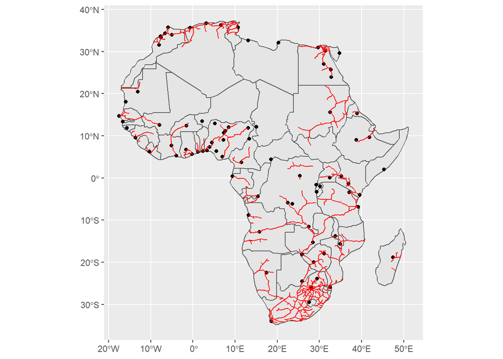

My classmate, *Jonathan Lee*, helped me complete this assignment by brainstorming with me about potential topics.